# Ford GoBike System

## by: Mustafa Ahmed

## Preliminary Wrangling

Ford GoBike is a bike-sharing system that allows people to use bikes as a transportation mean through different stations in San Francisco Bay Area.

```python
# import all packages and set plots to be embedded inline
import numpy as np
import pandas as pd
import matplotlib.pyplot as plt
import seaborn as sb

%matplotlib inline
```

```python
# Loading Ford GoBike dataset
go_bike = pd.read_csv('ford_go_bike.csv')
```

### Quick overview and descriptive statistics for the dataset

```python
go_bike.head()
```

|  | duration_sec | start_time | end_time | start_station_id | start_station_name | start_station_latitude | start_station_longitude | end_station_id | end_station_name | end_station_latitude | end_station_longitude | bike_id | user_type | member_birth_year | member_gender | bike_share_for_all_trip |
| --- | --- | --- | --- | --- | --- | --- | --- | --- | --- | --- | --- | --- | --- | --- | --- | --- |
| 0 | 52185 | 2019-02-28 17:32:10.1450 | 2019-03-01 08:01:55.9750 | 21.0 | Montgomery St BART Station (Market St at 2nd St) | 37.789625 | -122.400811 | 13.0 | Commercial St at Montgomery St | 37.794231 | -122.402923 | 4902 | Customer | 1984.0 | Male | No |
| 1 | 42521 | 2019-02-28 18:53:21.7890 | 2019-03-01 06:42:03.0560 | 23.0 | The Embarcadero at Steuart St | 37.791464 | -122.391034 | 81.0 | Berry St at 4th St | 37.775880 | -122.393170 | 2535 | Customer | NaN | NaN | No |
| 2 | 61854 | 2019-02-28 12:13:13.2180 | 2019-03-01 05:24:08.1460 | 86.0 | Market St at Dolores St | 37.769305 | -122.426826 | 3.0 | Powell St BART Station (Market St at 4th St) | 37.786375 | -122.404904 | 5905 | Customer | 1972.0 | Male | No |
| 3 | 36490 | 2019-02-28 17:54:26.0100 | 2019-03-01 04:02:36.8420 | 375.0 | Grove St at Masonic Ave | 37.774836 | -122.446546 | 70.0 | Central Ave at Fell St | 37.773311 | -122.444293 | 6638 | Subscriber | 1989.0 | Other | No |
| 4 | 1585 | 2019-02-28 23:54:18.5490 | 2019-03-01 00:20:44.0740 | 7.0 | Frank H Ogawa Plaza | 37.804562 | -122.271738 | 222.0 | 10th Ave at E 15th St | 37.792714 | -122.248780 | 4898 | Subscriber | 1974.0 | Male | Yes |

```python
go_bike.shape
```

```
(183412, 16)
```

```python
go_bike.dtypes
```

```
duration_sec                 int64
start_time                  object
end_time                    object
start_station_id           float64
start_station_name          object
start_station_latitude     float64
start_station_longitude    float64
end_station_id             float64
end_station_name            object
end_station_latitude       float64
end_station_longitude      float64
bike_id                      int64
user_type                   object
member_birth_year          float64
member_gender               object
bike_share_for_all_trip     object
dtype: object
```

```python
go_bike.describe()
```

|  | duration_sec | start_station_id | start_station_latitude | start_station_longitude | end_station_id | end_station_latitude | end_station_longitude | bike_id | member_birth_year |
| --- | --- | --- | --- | --- | --- | --- | --- | --- | --- |
| count | 183412.000000 | 183215.000000 | 183412.000000 | 183412.000000 | 183215.000000 | 183412.000000 | 183412.000000 | 183412.000000 | 175147.000000 |
| mean | 726.078435 | 138.590427 | 37.771223 | -122.352664 | 136.249123 | 37.771427 | -122.352250 | 4472.906375 | 1984.806437 |
| std | 1794.389780 | 111.778864 | 0.099581 | 0.117097 | 111.515131 | 0.099490 | 0.116673 | 1664.383394 | 10.116689 |
| min | 61.000000 | 3.000000 | 37.317298 | -122.453704 | 3.000000 | 37.317298 | -122.453704 | 11.000000 | 1878.000000 |
| 25% | 325.000000 | 47.000000 | 37.770083 | -122.412408 | 44.000000 | 37.770407 | -122.411726 | 3777.000000 | 1980.000000 |
| 50% | 514.000000 | 104.000000 | 37.780760 | -122.398285 | 100.000000 | 37.781010 | -122.398279 | 4958.000000 | 1987.000000 |
| 75% | 796.000000 | 239.000000 | 37.797280 | -122.286533 | 235.000000 | 37.797320 | -122.288045 | 5502.000000 | 1992.000000 |
| max | 85444.000000 | 398.000000 | 37.880222 | -121.874119 | 398.000000 | 37.880222 | -121.874119 | 6645.000000 | 2001.000000 |

```python
# Drop unnecessary columns: [start_station_id, start_station_latitude, start_station_longitude, end_station_id, end_station_latitude, end_station_longitude, bike_id]
go_bike.drop(columns= ['start_station_id','start_station_latitude', 'start_station_longitude', 'end_station_id', 'end_station_latitude', 'end_station_longitude', 'bike_id'], inplace= True)
```

```python
# Drop null values [almost 5% and will not affect our analysis dramatically]
print(go_bike.isnull().sum())
go_bike.dropna(inplace=True)
```

```
duration_sec                  0
start_time                    0
end_time                      0
start_station_name          197
end_station_name            197
user_type                     0
member_birth_year          8265
member_gender              8265
bike_share_for_all_trip       0
dtype: int64
```

```python
# Check for duplicates
go_bike.duplicated().sum()
```

```
0
```

```python
# change member_birth_year to integer
go_bike['member_birth_year']= go_bike['member_birth_year'].astype(int)
```

```python
# Change duration to minutes instead of seconds and rename column to (duration_min)
go_bike['duration_sec'] = (go_bike['duration_sec'] / 60).astype(int)
go_bike.rename(columns={'duration_sec':'duration_min'}, inplace=True)
```

```python
# Add new column 'age' by subtracting member_birth_year from 2019
go_bike['age'] = 2019 - go_bike['member_birth_year']
```

```python
# make sure all of the previous changes took place
go_bike.head()
```

|  | duration_min | start_time | end_time | start_station_name | end_station_name | user_type | member_birth_year | member_gender | bike_share_for_all_trip | age |
| --- | --- | --- | --- | --- | --- | --- | --- | --- | --- | --- |
| 0 | 869 | 2019-02-28 17:32:10.1450 | 2019-03-01 08:01:55.9750 | Montgomery St BART Station (Market St at 2nd St) | Commercial St at Montgomery St | Customer | 1984 | Male | No | 35 |
| 2 | 1030 | 2019-02-28 12:13:13.2180 | 2019-03-01 05:24:08.1460 | Market St at Dolores St | Powell St BART Station (Market St at 4th St) | Customer | 1972 | Male | No | 47 |
| 3 | 608 | 2019-02-28 17:54:26.0100 | 2019-03-01 04:02:36.8420 | Grove St at Masonic Ave | Central Ave at Fell St | Subscriber | 1989 | Other | No | 30 |
| 4 | 26 | 2019-02-28 23:54:18.5490 | 2019-03-01 00:20:44.0740 | Frank H Ogawa Plaza | 10th Ave at E 15th St | Subscriber | 1974 | Male | Yes | 45 |
| 5 | 29 | 2019-02-28 23:49:58.6320 | 2019-03-01 00:19:51.7600 | 4th St at Mission Bay Blvd S | Broadway at Kearny | Subscriber | 1959 | Male | No | 60 |

```python
print(go_bike.shape)
```

```
(174952, 10)
```

### What is the structure of your dataset?

After adjusting the dataset, we have 10 columns(duration_min, start_time, end_time, start_station_name, end_station_name, user_type, member_birth_year, member_gender, bike_share_for_all_trip, age) with 174952 observations.

### What is/are the main feature(s) of interest in your dataset?

We need to focus on number of trips/users and duration.

### What features in the dataset do you think will help support your investigation into your feature(s) of interest?

I think duration and number of trips/users are affected by age, gender, day of the week and user type.

## Univariate Exploration

We will try to figure out how duration is distributed

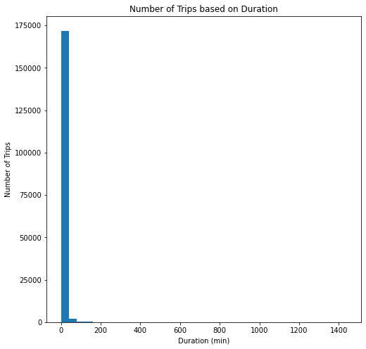

```python
# Plotting the relation between number of the trips and duration
binsize= 40
bins = np.arange(0, go_bike['duration_min'].max()+binsize, binsize)

plt.figure(figsize=[8, 8])
plt.hist(data = go_bike, x = 'duration_min', bins = bins);
plt.xlabel('Duration (min)')
plt.ylabel('Number of Trips')
plt.title('Number of Trips based on Duration');
```

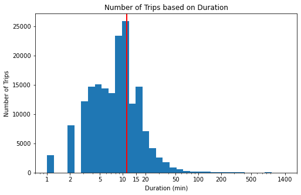

```python
# To make it clear, we will use a log scale for the -duration plot
log_binsize = .09
bins = 10 ** np.arange(0, np.log10(go_bike['duration_min'].max())+log_binsize, log_binsize)

plt.figure(figsize=[8, 5])
plt.hist(data = go_bike, x = 'duration_min', bins = bins)
plt.xscale('log')
ticks = [1, 2, 5, 10, 15, 20, 50, 100, 200, 500, 1400]
plt.xticks(ticks, ticks)
plt.xlabel('Duration (min)')
plt.ylabel('Number of Trips')
plt.title('Number of Trips based on Duration');

# Plotting vertical line showing the mean
plt.axvline(go_bike['duration_min'].mean(), color='r', lw=2);
```

Now, we will see gender distribution

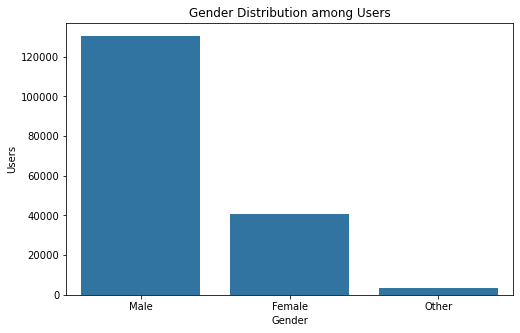

```python
# Plotting relation between Gender and Number of Users
plt.figure(figsize=[8,5])
sb.countplot(data = go_bike, x = 'member_gender',color = sb.color_palette()[0], order = go_bike['member_gender'].value_counts().index);
plt.xlabel('Gender')
plt.ylabel('Users')
plt.title('Gender Distribution among Users');
```

Previous plot shows that most of our users are male.

Let's see age distribution

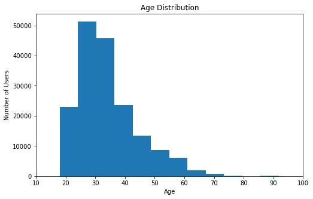

```python
# Plotting relation Age and between Number of Trips
plt.figure(figsize=[8,5])

plt.hist(data = go_bike, x = 'age', bins = 20);
plt.xlim([10,100]) #limiting age between 10 and 100 (more than 100 is not logic)
plt.xlabel('Age')
plt.ylabel('Number of Users')
plt.title('Age Distribution');
```

Age of users increases and reach its peak around 30 years. After that duration is going down.

Now, with user type distribution

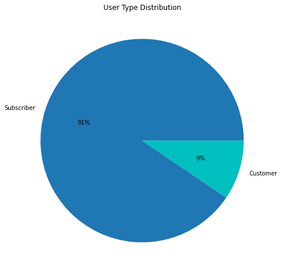

```python
# Showing percentage of subscribers and customers
plt.figure(figsize=[8,8])
plt.pie(go_bike['user_type'].value_counts(), labels=['Subscriber','Customer'], autopct='%1.0f%%', colors=['tab:blue', 'c'])
plt.title('User Type Distribution');
```

People who subscribed to our service equal 10 times regular customers

Let's see which are our top 10 start and end stations

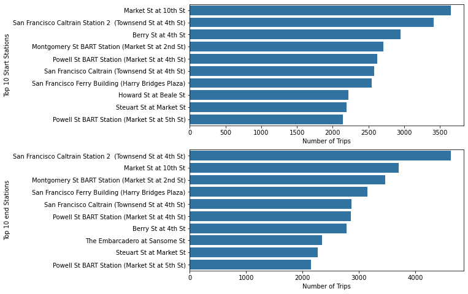

```python
# creating subplot showing Top 10 start and end stations
fig, ax = plt.subplots(nrows=2, figsize = [8,8])

# Top 10 start stations
sb.countplot(data = go_bike, y = 'start_station_name', color = sb.color_palette()[0],
        order = go_bike['start_station_name'].value_counts().index[0:10], ax = ax[0])

ax[0].set_ylabel('Top 10 Start Stations')
ax[0].set_xlabel('Number of Trips')

# Top 10 end stations
sb.countplot(data = go_bike, y = 'end_station_name', color = sb.color_palette()[0],
        order = go_bike['end_station_name'].value_counts().index[0:10], ax = ax[1])

ax[1].set_ylabel('Top 10 end Stations')
ax[1].set_xlabel('Number of Trips');
```

'Market St at 10th St' and 'San Francisco Caltrain Station 2' are the most popular stations (as start and end stations)

Here, we get to the effect of weekdays and weekends

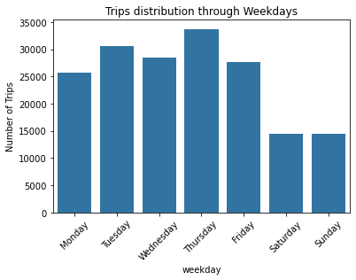

```python
# changing start time type to datetime
go_bike.start_time = pd.to_datetime(go_bike.start_time)

# Add new column for days
go_bike['weekday'] = go_bike.start_time.dt.weekday

# Plotting number of starting trips feo each weekday
s= sb.countplot(data = go_bike, x = 'weekday', color = sb.color_palette()[0] )
s.set_xticklabels(['Monday', 'Tuesday', 'Wednesday', 'Thursday', 'Friday', 'Saturday','Sunday'])
plt.ylabel('Number of Trips');
plt.xticks(rotation=45);
plt.title('Trips distribution through Weekdays');
```

The last plot indicates that trips in weekday are more than weekends.

### Discuss the distribution(s) of your variable(s) of interest. Were there any unusual points? Did you need to perform any transformations?

Number of trips increase as long as gender is male, user is subscriber. Also, there are more trips on weekday than weekends and that's normal.

### Of the features you investigated, were there any unusual distributions? Did you perform any operations on the data to tidy, adjust, or change the form of the data? If so, why did you do this?

I created a new column for age and found that there are users above 100, so when plotting i limited the age to 100. To get weekday column, I changed 'start_time' type to datetype and extracted days from that column.

## Bivariate Exploration

We start our bivariate exploration with the relation between duration and age

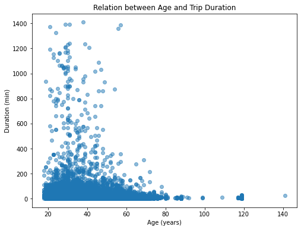

```python
# Plotting relation between Age and Trip Duration
plt.figure(figsize = [8, 6])
plt.scatter(data = go_bike, x = 'age', y = 'duration_min', alpha = .5)
plt.xlabel('Age (years)')
plt.ylabel('Duration (min)')
plt.title('Relation between Age and Trip Duration');
```

As age increases, trip duration decreases. Longer trips are related to people from 20 to 40, and most of trips last less than 30 minutes

Now, we move to the relation between gender and duration

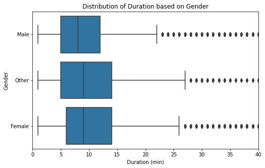

```python
# This plot shows distribution of Duration based on Gender
plt.figure(figsize = [8, 5])
sb.boxplot(data = go_bike, y = 'member_gender', x = 'duration_min', color = sb.color_palette()[0])

plt.xlim([0, 40])
plt.xlabel('Duration (min)')
plt.ylabel('Gender')
plt.title('Distribution of Duration based on Gender');
```

Female users take a slight longer trips than other gender.

Let's see the relation between user type and duration

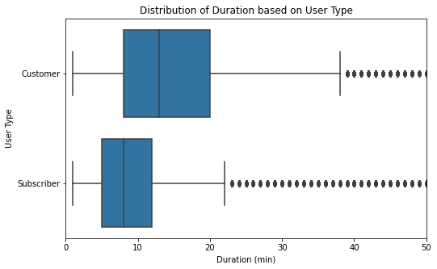

```python
plt.figure(figsize = [8, 5])
sb.boxplot(data = go_bike, y = 'user_type', x = 'duration_min', color = sb.color_palette()[0])
plt.xlim([0, 50])
plt.xlabel('Duration (min)')
plt.ylabel('User Type')
plt.title('Distribution of Duration based on User Type');
```

Customers take longer trips than Subscribers.

And here is the relation between weekday and trip duration

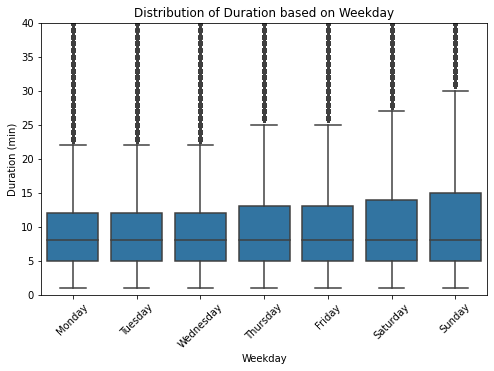

```python
plt.figure(figsize = [8, 5])
a= sb.boxplot(data = go_bike, x = 'weekday', y = 'duration_min', color = sb.color_palette()[0])
plt.ylim([0, 40])
a.set_xticklabels(['Monday', 'Tuesday', 'Wednesday', 'Thursday', 'Friday', 'Saturday','Sunday'])
plt.xticks(rotation=45)
plt.ylabel('Duration (min)')
plt.xlabel('Weekday')
plt.title('Distribution of Duration based on Weekday');
```

### Talk about some of the relationships you observed in this part of the investigation. How did the feature(s) of interest vary with other features in the dataset?

Trip Duration has a negative correlation against Age and There is a slight difference in trip duration against different features such as(gender, and user type)

### Did you observe any interesting relationships between the other features (not the main feature(s) of interest)?

It's strange to see customer takes longer trips than subscribers, as that means higher fare.

## Multivariate Exploration

We will start with the relation between number of the trips throughout the week, associated with gender

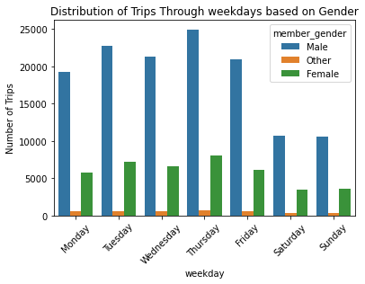

```python
# Plotting number of starting trips for each weekday for different genders
s= sb.countplot(data = go_bike, x = 'weekday', hue='member_gender')
s.set_xticklabels(['Monday', 'Tuesday', 'Wednesday', 'Thursday', 'Friday', 'Saturday','Sunday'])
plt.ylabel('Number of Trips')
plt.xticks(rotation=45)
plt.title('Distribution of Trips Through weekdays based on Gender');
```

Male trips are obviously the dominant by 3 or 4 times through the week.

To dig deeper, we will see the relation between duration, age and gender.

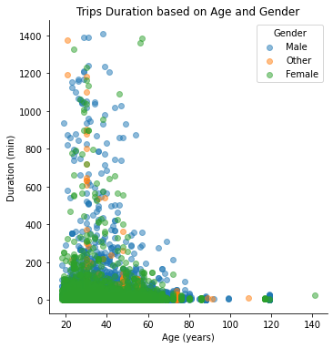

```python
# Plotting Trips Duration based on Age and Gender
sb.lmplot(data= go_bike, x='age' , y="duration_min",  fit_reg=False, hue='member_gender', legend=False, scatter_kws={'alpha':0.5})
plt.legend(title ='Gender')

plt.xlabel('Age (years)')
plt.ylabel('Duration (min)')
plt.title('Trips Duration based on Age and Gender');
```

We will see how gender distributed regarding usre type

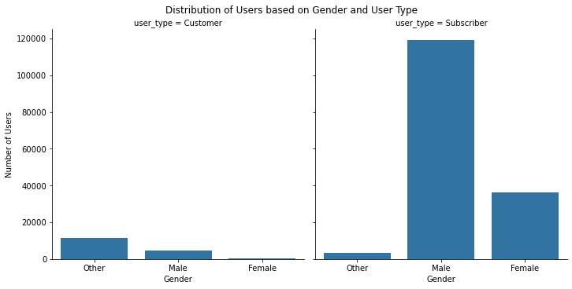

```python
# Plotting Users based on User Type and Gender
g = sb.FacetGrid(data = go_bike, col = 'user_type', height = 5, aspect =1)
g.map_dataframe(sb.countplot, 'member_gender', alpha= None)
g.set_axis_labels('Gender', 'Number of Users')
g.fig.suptitle('Distribution of Users based on Gender and User Type', va= 'bottom');
```

```python
# Save cleaned data as a CSV file
go_bike.to_csv('go_bike_cleaned.csv', index=False)
```

### Talk about some of the relationships you observed in this part of the investigation. Were there features that strengthened each other in terms of looking at your feature(s) of interest?

There is almost no effect for gender on the relation between duration and age or weekday and number of users